# 103.1-Klamath-estuary-GonadSI-power-analysis

Neil Thompson

Last Updated: 2020-05-14

We decided to do a power analysis to answer the question, “what difference in gonadosomatic index values would need to be present in the data to have a significant random intercept effect in model selection between a non-mixed model and a mixed effect model (RoSA=random)?”

# Developing the Power Analysis

```r
library(tidyverse)
library(cowplot)
library(nlme)

dir.create("./outputs/103.1/", recursive = TRUE, showWarnings = FALSE)
```

```r
rosa_data <- read_rds("./data/101-RoSA-klamath-estuary-samples.rds")

estuary_meta <- read_csv("./data/102-Klamath-entryDATA_withNMFSID.csv")
rosa_meta <- left_join(estuary_meta, rosa_data, by = c("NMFS ID" = "NMFS_DNA_ID")) %>%
  dplyr::select(-ID) %>%
  rename(NMFS_DNA_ID = "NMFS ID") %>%
  dplyr::select(NMFS_DNA_ID, rosa, everything())
```

Remove all samples with ANY missing data. And remove the recombinant genotypes. For this analysis I’m going to use estuary data from 2010 only. This is because there are only 12 EL fish sampled in 2009 which is a really small sample to estimate variance from. The larger EL sample size in 2010 (n=52) will be generate a more robust analysis.

```r
stat_data <- rosa_meta %>%
  rename(gonadsi = gsi) %>%
  filter(
    rosa %in% c("EEEEEEEE", "HHHHHHHH", "LLLLLLLL"),
    year == "2010"
  ) %>%
  mutate(
    log_est = log(julian),
    log_est2 = log_est^2
  )
```

To simulate realistic data I am going to do simple linear regression on the data subsetted by RoSA genotype. From that I can estimate the gonadosomatic index values quite precisely. I’m going to simulate a single years worth of data to keep the power analysis simplified.

```r
m_only <- stat_data %>% filter(rosa == "LLLLLLLL")
lm(gonadsi ~ 1 + log_est + log_est2 + sex, m_only)
```

```
##
## Call:
## lm(formula = gonadsi ~ 1 + log_est + log_est2 + sex, data = m_only)
##
## Coefficients:
## (Intercept)      log_est     log_est2         sexm
##     2.54219     -1.00516      0.10010     -0.01662
```

To generate variance in the data I’ll need the standard deviations of gonadsi for each sex.

```r
stat_data %>%
  filter(rosa == "LLLLLLLL") %>%
  group_by(sex) %>%
  summarise(
    mean_gonad = mean(gonadsi), sd_gonad = sd(gonadsi),
    mean_logestuarydate = mean(log_est), sd_logestuarydate = sd(log_est)
  )
```

| sex | mean_gonad | sd_gonad | mean_logestuarydate | sd_logestuarydate |
| --- | --- | --- | --- | --- |
| f | 0.04109793 | 0.01435360 | 5.485705 | 0.07431736 |
| m | 0.02594774 | 0.01211973 | 5.500331 | 0.08003071 |

The linear regression effect values and standard deviations will be used to simulate the LL RoSA data.

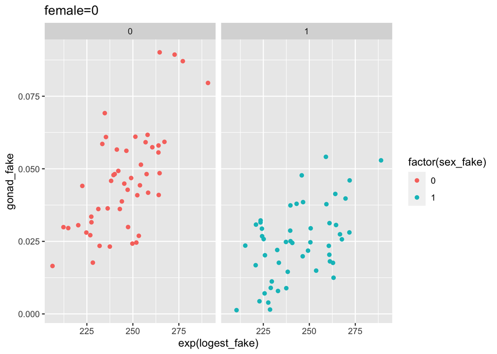

```r
int <- 2.54219
log_esteffect <- -1.00516
log_est2effect <- 0.10010
sex_effect <- -.01662

fd1 <- tibble(
  logest_fake = rnorm(n = 100, mean = 5.49, sd = 0.08), # generates 100 random estuary entry dates based on mean entry date and SD from 2010 data
  logest2_fake = logest_fake^2,
  RoSA = "LL",
  sex_fake = rep(0:1, each = 50), # create 50 males and 50 females
  eps_female = rnorm(n = 100, mean = 0, sd = 0.0144), # error for females
  eps_male = rnorm(n = 100, mean = 0, sd = 0.0121), # error for females
  gonad_est = int + log_esteffect * logest_fake + log_est2effect * logest2_fake + sex_effect * sex_fake, # produce estimate from linear regression
  gonad_fake = ifelse(sex_fake == 1, gonad_est + eps_male, gonad_est + eps_female)
) %>% # add variance into estimate based on sex of individual
  filter(gonad_fake > 0)

ggplot(fd1, aes(x = exp(logest_fake), y = gonad_fake, colour = factor(sex_fake))) +
  geom_point() +
  facet_wrap(sex_fake ~ .) +
  ggtitle("female=0")
```

Cool, that appears to be ok for LL fish.

```r
e_only <- stat_data %>% filter(rosa == "EEEEEEEE")
lm(gonadsi ~ log_est + log_est2 + sex, e_only)
```

```
##
## Call:
## lm(formula = gonadsi ~ log_est + log_est2 + sex, data = e_only)
##
## Coefficients:
## (Intercept)      log_est     log_est2         sexm
##     0.82412     -0.34246      0.03621     -0.01331
```

To generate variance in the data I’ll need the standard deviations of gonadsi for each sex.

```r
stat_data %>%
  filter(rosa == "EEEEEEEE") %>%
  group_by(sex) %>%
  summarise(
    mean_gonad = mean(gonadsi), sd_gonad = sd(gonadsi),
    mean_logestuarydate = mean(log_est), sd_logestuarydate = sd(log_est)
  )
```

| sex | mean_gonad | sd_gonad | mean_logestuarydate | sd_logestuarydate |
| --- | --- | --- | --- | --- |
| f | 0.018513658 | 0.007025174 | 5.046207 | 0.1204439 |
| m | 0.005339645 | 0.002571392 | 5.057763 | 0.1034945 |

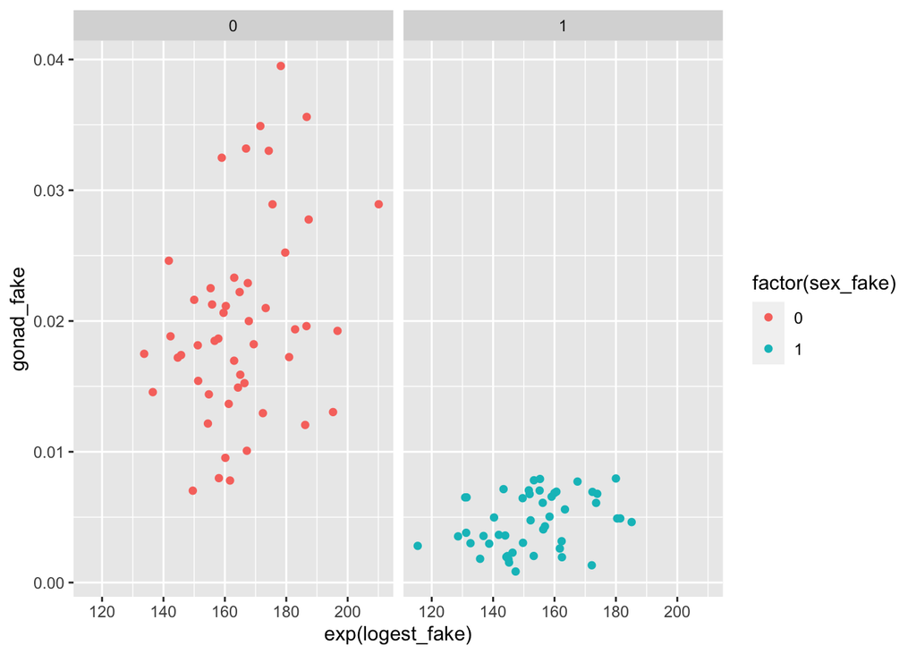

```r
int <- 0.82412
log_esteffect <- -0.34246
log_est2effect <- 0.03621
sex_effect <- -0.01331

fd2 <- tibble(
  logest_fake = rnorm(n = 100, mean = 5.05, sd = 0.11), # mean and SD from 2009 data
  logest2_fake = logest_fake^2,
  RoSA = "EE",
  sex_fake = rep(0:1, each = 50),
  eps_female = rnorm(n = 100, mean = 0, sd = 0.0070),
  eps_male = rnorm(n = 100, mean = 0, sd = 0.0026),
  gonad_est = int + log_esteffect * logest_fake + log_est2effect * logest2_fake + sex_effect * sex_fake,
  gonad_fake = ifelse(sex_fake == 1, gonad_est + eps_male, gonad_est + eps_female)
) %>%
  filter(gonad_fake > 0)

ggplot(fd2, aes(x = exp(logest_fake), y = gonad_fake, colour = factor(sex_fake))) +
  geom_point() +
  facet_wrap(sex_fake ~ .)
```

heterozygote linear regression

```r
h_only <- stat_data %>% filter(rosa == "HHHHHHHH")
lm(gonadsi ~ log_est + log_est2 + sex, h_only)
```

```
##
## Call:
## lm(formula = gonadsi ~ log_est + log_est2 + sex, data = h_only)
##
## Coefficients:
## (Intercept)      log_est     log_est2         sexm
##     0.87697     -0.37153      0.04004     -0.02044
```

To generate variance in the data I’ll need the standard deviations of gonadsi for each sex.

```r
stat_data %>%
  filter(rosa == "HHHHHHHH") %>%
  group_by(sex) %>%
  summarise(
    mean_gonad = mean(gonadsi), sd_gonad = sd(gonadsi),
    mean_logestuarydate = mean(log_est), sd_logestuarydate = sd(log_est)
  )
```

| sex | mean_gonad | sd_gonad | mean_logestuarydate | sd_logestuarydate |
| --- | --- | --- | --- | --- |
| f | 0.03143172 | 0.018442718 | 5.274008 | 0.08768787 |
| m | 0.01048712 | 0.004558035 | 5.265228 | 0.07754555 |

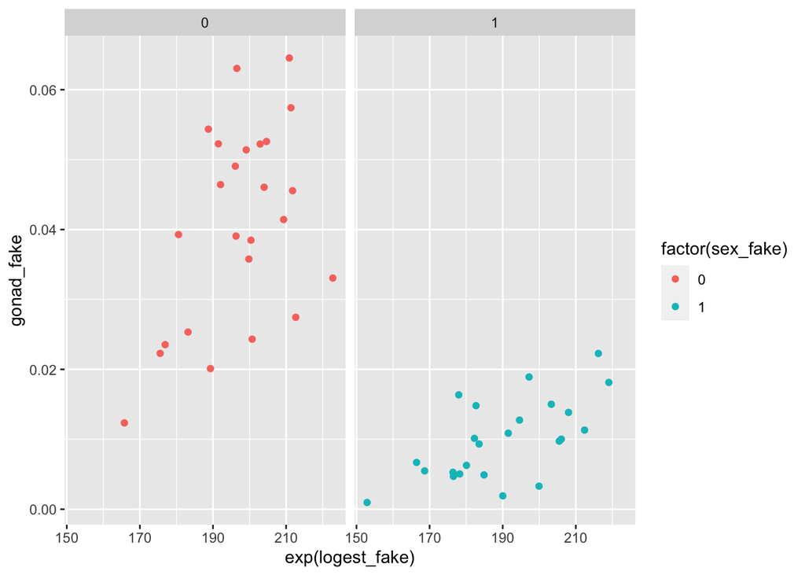

```r
int <- 0.87697
log_esteffect <- -0.37153
log_est2effect <- 0.04004
sex_effect <- -0.02044

fd3 <- tibble(
  logest_fake = rnorm(n = 50, mean = 5.27, sd = 0.08), # mean and SD from 2009
  logest2_fake = logest_fake^2,
  RoSA = "EL",
  sex_fake = rep(0:1, each = 25),
  eps_female = rnorm(n = 50, mean = 0, sd = 0.0184),
  eps_male = rnorm(n = 50, mean = 0, sd = 0.0046),
  gonad_est = int + log_esteffect * logest_fake + log_est2effect * logest2_fake + sex_effect * sex_fake,
  gonad_fake = ifelse(sex_fake == 1, gonad_est + eps_male, gonad_est + eps_female)
) %>%
  filter(gonad_fake > 0)

ggplot(fd3, aes(x = exp(logest_fake), y = gonad_fake, colour = factor(sex_fake))) +
  geom_point() +
  facet_wrap(sex_fake ~ .)
```

join the simulated EE, EL and LL data frames together and plot it. This plot should look pretty damn similar to the real data.

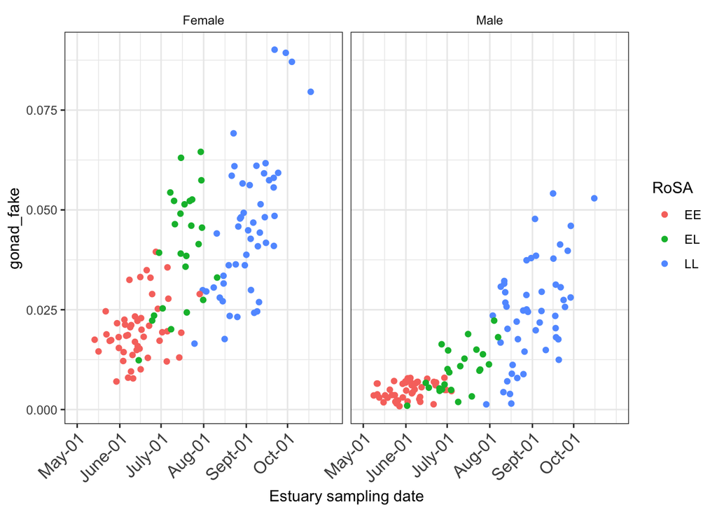

```r
lm_sim <- bind_rows(fd1, fd2, fd3)

sex_names <- list(
  "0" = "Female",
  "1" = "Male"
)

plot_labeller <- function(variable, value) {
  return(sex_names[value])
}

ggplot(lm_sim, aes(x = exp(logest_fake), y = gonad_fake, colour = RoSA)) +
  geom_point() +
  facet_wrap(sex_fake ~ .) +
  scale_x_continuous(
    name = "Estuary sampling date", limits = c(121, 305), breaks = c(121, 152, 182, 213, 244, 274),
    labels = c("May-01", "June-01", "July-01", "Aug-01", "Sept-01", "Oct-01")
  ) +
  theme_bw() +
  theme(
    axis.text.x = element_text(angle = 45, hjust = 1, size = 12),
    strip.background = element_blank()
  ) +
  facet_grid(. ~ factor(sex_fake), labeller = plot_labeller)
```

Cool, I think that looks pretty good. Now I’ll just need to add in the estimated early allele effect as the code above simply generates data that is similar to the real gonadosomatic index data.

I’ll assume an additive model here too. For every E allele in the RoSA genotype the gonadosomatic index will increase by X units. This will be straightforward to add into the data generation in a function.

WRAP INTO FUNCTION FOR POWER ANALYSIS. Let’s make a simulated data generation function first.

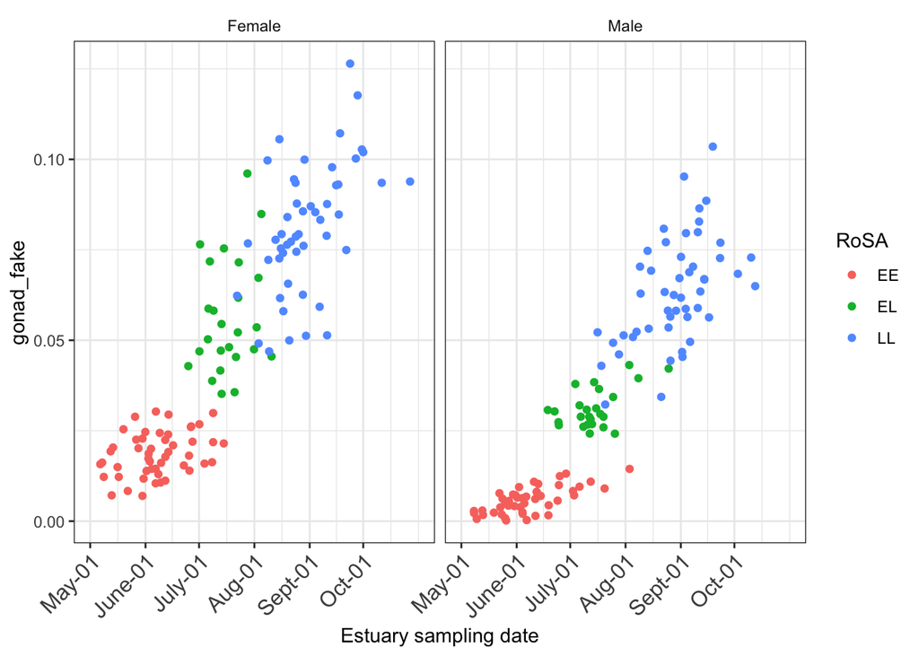

```r
gonad_data <- function(allele_effect, pop_size) {
  # EE data
  int <- 0.82412
  log_esteffect <- -0.34246
  log_est2effect <- 0.03621
  sex_effect <- -0.01331

  fake_ee <- tibble(
    logest_fake = rnorm(n = 100, mean = 5.05, sd = 0.11), # mean and SD from 2010 data
    logest2_fake = logest_fake^2,
    RoSA = "EE",
    sex_fake = rep(0:1, each = 50),
    eps_female = rnorm(n = 100, mean = 0, sd = 0.0070),
    eps_male = rnorm(n = 100, mean = 0, sd = 0.0026),
    gonad_est = int + log_esteffect * logest_fake + log_est2effect * logest2_fake + sex_effect * sex_fake,
    gonad_var = ifelse(sex_fake == 1, gonad_est + eps_male, gonad_est + eps_female),
    gonad_fake = gonad_var
  ) %>%
    filter(gonad_fake > 0)

  # EL data
  int <- 0.87697
  log_esteffect <- -0.37153
  log_est2effect <- 0.04004
  sex_effect <- -0.02044

  fake_el <- tibble(
    logest_fake = rnorm(n = pop_size / 2, mean = 5.27, sd = 0.08),
    logest2_fake = logest_fake^2,
    RoSA = "EL",
    sex_fake = rep(0:1, each = pop_size / 4),
    eps_female = rnorm(n = pop_size / 2, mean = 0, sd = 0.0184),
    eps_male = rnorm(n = pop_size / 2, mean = 0, sd = 0.0046),
    gonad_est = int + log_esteffect * logest_fake + log_est2effect * logest2_fake + sex_effect * sex_fake,
    gonad_var = ifelse(sex_fake == 1, gonad_est + eps_male, gonad_est + eps_female),
    gonad_fake = gonad_var + allele_effect
  ) %>%
    filter(gonad_fake > 0)

  # LL data
  int <- 2.54219
  log_esteffect <- -1.00516
  log_est2effect <- 0.10010
  sex_effect <- -.01662

  fake_ll <- tibble(
    logest_fake = rnorm(n = pop_size, mean = 5.49, sd = 0.08),
    logest2_fake = logest_fake^2,
    RoSA = "LL",
    sex_fake = rep(0:1, each = pop_size / 2),
    eps_female = rnorm(n = pop_size, mean = 0, sd = 0.0144),
    eps_male = rnorm(n = pop_size, mean = 0, sd = 0.0121),
    gonad_est = int + log_esteffect * logest_fake + log_est2effect * logest2_fake + sex_effect * sex_fake,
    gonad_var = ifelse(sex_fake == 1, gonad_est + eps_male, gonad_est + eps_female),
    gonad_fake = gonad_var + 2 * allele_effect
  ) %>%
    filter(gonad_fake > 0)

  lm_sim <- bind_rows(fake_ee, fake_el, fake_ll) %>%
    mutate(RoSA = factor(RoSA, levels = c("EE", "EL", "LL")))
  lm_sim
}

tmp1 <- gonad_data(allele_effect = 0.02, pop_size = 100) # each L haplo increases gsi by 2 units.

ggplot(tmp1, aes(x = exp(logest_fake), y = gonad_fake, colour = RoSA)) +
  geom_point() +
  facet_wrap(sex_fake ~ .) +
  scale_x_continuous(
    name = "Estuary sampling date", limits = c(121, 305), breaks = c(121, 152, 182, 213, 244, 274),
    labels = c("May-01", "June-01", "July-01", "Aug-01", "Sept-01", "Oct-01")
  ) +
  theme_bw() +
  theme(
    axis.text.x = element_text(angle = 45, hjust = 1, size = 12),
    strip.background = element_blank()
  ) +
  facet_grid(. ~ factor(sex_fake), labeller = plot_labeller)
```

The function appears to be working as I want it to. Let’s see if an early allele effect of 0.02 produces a statistically significant random intercept

```r
logest2Power <- varPower(form = ~logest2_fake)

power_tmp <- gls(gonad_fake ~ 1 + logest_fake + logest2_fake + sex_fake, weights = logest2Power, data = tmp1) # remove the year factor, simulate a single year of data.

power_mm_tmp <- lme(gonad_fake ~ 1 + logest_fake + logest2_fake + sex_fake, random = ~ 1 | RoSA, method = "REML", weights = logest2Power, data = tmp1) # random intercept model

anova(power_tmp, power_mm_tmp)
```

|  | call | Model | df | AIC | BIC | logLik | Test | L.Ratio | p-value |
| --- | --- | --- | --- | --- | --- | --- | --- | --- | --- |
| power_tmp | gls(model = gonad_fake ~ 1 + logest_fake + logest2_fake + sex_fake, data = tmp1, weights = logest2Power) | 1 | 6 | -1444.212 | -1423.253 | 728.1058 |  | NA | NA |
| power_mm_tmp | lme.formula(fixed = gonad_fake ~ 1 + logest_fake + logest2_fake + sex_fake, data = tmp1, random = ~1 \| RoSA, weights = logest2Power, method = "REML") | 2 | 7 | -1552.103 | -1527.651 | 783.0514 | 1 vs 2 | 109.8913 | 1.035147e-25 |

Make a function that incorporates the model selection between a GLS and mixed effects model (random intercept)

```r
gonad_data_pwr_analysis <- function(allele_effect, pop_size) {
  # EE data
  int <- 0.82412
  log_esteffect <- -0.34246
  log_est2effect <- 0.03621
  sex_effect <- -0.01331

  fake_ee <- tibble(
    logest_fake = rnorm(n = 100, mean = 5.05, sd = 0.11), # mean and SD from 2010 data
    logest2_fake = logest_fake^2,
    RoSA = "EE",
    sex_fake = rep(0:1, each = 50),
    eps_female = rnorm(n = 100, mean = 0, sd = 0.0070),
    eps_male = rnorm(n = 100, mean = 0, sd = 0.0026),
    gonad_est = int + log_esteffect * logest_fake + log_est2effect * logest2_fake + sex_effect * sex_fake,
    gonad_var = ifelse(sex_fake == 1, gonad_est + eps_male, gonad_est + eps_female),
    gonad_fake = gonad_var
  ) %>%
    filter(gonad_fake > 0)

  # EL data
  int <- 0.87697
  log_esteffect <- -0.37153
  log_est2effect <- 0.04004
  sex_effect <- -0.02044

  fake_el <- tibble(
    logest_fake = rnorm(n = pop_size / 2, mean = 5.27, sd = 0.08),
    logest2_fake = logest_fake^2,
    RoSA = "EL",
    sex_fake = rep(0:1, each = pop_size / 4),
    eps_female = rnorm(n = pop_size / 2, mean = 0, sd = 0.0184),
    eps_male = rnorm(n = pop_size / 2, mean = 0, sd = 0.0046),
    gonad_est = int + log_esteffect * logest_fake + log_est2effect * logest2_fake + sex_effect * sex_fake,
    gonad_var = ifelse(sex_fake == 1, gonad_est + eps_male, gonad_est + eps_female),
    gonad_fake = gonad_var + allele_effect
  ) %>%
    filter(gonad_fake > 0)

  # LL data
  int <- 2.54219
  log_esteffect <- -1.00516
  log_est2effect <- 0.10010
  sex_effect <- -.01662

  fake_ll <- tibble(
    logest_fake = rnorm(n = pop_size, mean = 5.49, sd = 0.08),
    logest2_fake = logest_fake^2,
    RoSA = "LL",
    sex_fake = rep(0:1, each = pop_size / 2),
    eps_female = rnorm(n = pop_size, mean = 0, sd = 0.0144),
    eps_male = rnorm(n = pop_size, mean = 0, sd = 0.0121),
    gonad_est = int + log_esteffect * logest_fake + log_est2effect * logest2_fake + sex_effect * sex_fake,
    gonad_var = ifelse(sex_fake == 1, gonad_est + eps_male, gonad_est + eps_female),
    gonad_fake = gonad_var + 2 * allele_effect
  ) %>%
    filter(gonad_fake > 0)

  lm_sim <- bind_rows(fake_ee, fake_el, fake_ll) %>%
    mutate(RoSA = factor(RoSA, levels = c("EE", "EL", "LL")))

  logest2Power <- varPower(form = ~logest2_fake)

  power_tmp <- gls(gonad_fake ~ 1 + logest_fake + logest2_fake + sex_fake, weights = logest2Power, data = lm_sim) # remove the year factor, simulate a single year of data.

  power_mm_tmp <- lme(gonad_fake ~ 1 + logest_fake + logest2_fake + sex_fake, random = ~ 1 | RoSA, method = "REML", weights = logest2Power, data = lm_sim) # random intercept model


  p_val <- anova(power_tmp, power_mm_tmp)$"p-value"[2]

  p_val
}
```

# Run the power analysis simulation

Run model selection 1000 times and see how many times the mixed effects model is preferred over the GLS

```r
rep_outp <- replicate(1e3, gonad_data_pwr_analysis(allele_effect = 0.02, pop_size = 100))

table(rep_outp <= 0.05)
```

```
##
## TRUE
## 1000
```

Wow, I’m surprised by that. But it’s good news for the gonadosomatic index analysis!

What effect size would 80% power be achieved? This is going to be smaller than I expected. Only do 250 simulated data sets for each effect size, here.

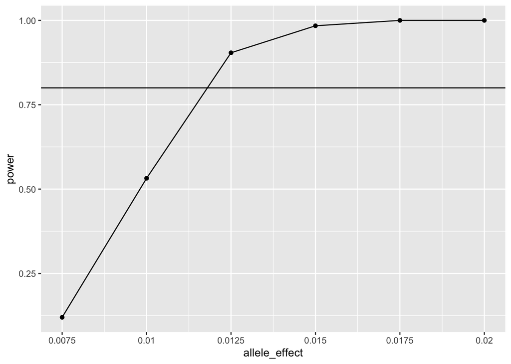

```r
alpha <- 0.05
power_table <- tibble(
  allele_effect = seq(0.0075, 0.02, by = 0.0025)
) %>%
  mutate(power = map_dbl(allele_effect, function(allele_effect) {
    ps <- replicate(250, gonad_data_pwr_analysis(allele_effect = allele_effect, pop_size = 100))
    mean(ps < alpha)
  }))

ggplot(power_table, aes(allele_effect, power)) +
  geom_point() +
  geom_line() +
  scale_x_continuous(limits = c(0.0075, 0.02), breaks = c(0.0075, 0.01, 0.0125, 0.0150, 0.0175, 0.02), labels = c(0.0075, 0.01, 0.0125, 0.0150, 0.0175, 0.02)) +
  geom_hline(yintercept = 0.8)
```

```r
ggsave("./outputs/103.1/allele_effect_gonadsi_power_simulation.pdf")
```

Wow, so we could find a statistically significant random intercept effect with as little as 0.024 gonadsi units separating EE and LL genotypes.

Now make a 2x2 matrix figure to show what the data would look like with an allele effect of 0.012 per L haplotype.

```r
sex_names <- list(
  "0" = "Female",
  "1" = "Male"
)

plot_labeller <- function(variable, value) {
  return(sex_names[value])
}
```

Set up some functions to simulate 20 data sets and do all the calculations on them and then keep the first four that are significant (just to see what they look like).

Simulation 1 for the figure. Make sure the ANOVA is significant, it it turns out not to be significant re-run the code chunk until you get a significant result.

```r
plot_simmed_data <- function(tmp1) {
  ggplot(tmp1, aes(x = exp(logest_fake), y = gonad_fake, colour = RoSA)) +
    geom_point() +
    facet_wrap(sex_fake ~ .) +
    scale_x_continuous(
      name = "Estuary sampling date", limits = c(121, 349), breaks = c(121, 152, 182, 213, 244, 274, 305, 335),
      labels = c("May-01", "June-01", "July-01", "Aug-01", "Sept-01", "Oct-01", "Nov-01", "Dec-01")
    ) +
    scale_y_continuous(
      name = "fake gonadosomatic index", limits = c(0, 0.15), breaks = c(0, 0.05, 0.10, 0.15),
      labels = c(0, 0.05, 0.10, 0.15)
    ) +
    theme_bw() +
    theme(
      axis.text.x = element_text(angle = 45, hjust = 1, size = 12),
      strip.background = element_blank()
    ) +
    facet_grid(. ~ factor(sex_fake), labeller = plot_labeller)
}

power_non_mixed <- function(tmp1) {
  gls(gonad_fake ~ 1 + logest_fake + logest2_fake + sex_fake, weights = logest2Power, data = tmp1) # remove the year factor, simulate a single year of data.
}
power_mixed <- function(tmp1) {
  power_mm_tmp1 <- lme(gonad_fake ~ 1 + logest_fake + logest2_fake + sex_fake, random = ~ 1 | RoSA, method = "REML", weights = logest2Power, data = tmp1) # random intercept model
}
```

Now, simulate 20 data sets and analyze them. Keep it all in a tibble:

```r
set.seed(25) # for reproducibility
sim_tibble <- tibble(
  data_sets = lapply(1:20, function(x) gonad_data(allele_effect = 0.012, pop_size = 100))
) %>%
  mutate(
    plots = map(data_sets, plot_simmed_data),
    power_M = map(data_sets, power_non_mixed),
    power_mm = map(data_sets, power_mixed),
    anova = map2(power_M, power_mm, .f = anova),
    p_value = map_dbl(anova, ~ .$`p-value`[2]),
    ranef = map(power_mm, ranef)
  )
```

Now, keep the first 4 that have a p-value < 0.05 and put their plots together:

```r
signif_4 <- sim_tibble %>%
  filter(p_value < 0.05) %>%
  slice(1:4)
```

Let’s look at the randome effect intercepts of those:

```r
signif_4$ranef
```

```
## [[1]]
##     (Intercept)
## EE -0.010820273
## EL  0.002593675
## LL  0.008226598
##
## [[2]]
##     (Intercept)
## EE -0.011327176
## EL  0.001659429
## LL  0.009667747
##
## [[3]]
##     (Intercept)
## EE -0.011307137
## EL -0.000173805
## LL  0.011480942
##
## [[4]]
##     (Intercept)
## EE -0.012122234
## EL  0.003263334
## LL  0.008858900
```

And the p-values:

```r
signif_4$p_value
```

```
## [1] 7.483650e-10 3.225608e-11 8.248858e-11 2.823935e-08
```

Plot the 4 simulated data sets.

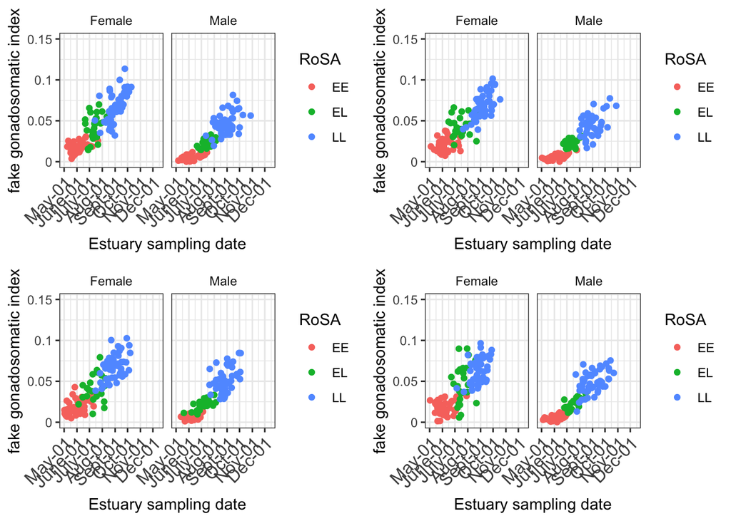

```r
plot_grid(signif_4$plots[[1]],
  signif_4$plots[[2]],
  signif_4$plots[[3]],
  signif_4$plots[[4]],
  ncol = 2
)
```

```r
ggsave("./outputs/103.1/simulated_gonadosomatic_index_sampling_date_faceted.pdf", width = 16, height = 10)
```

This plot graphically represents the difference in gonadosomatic index among EE, EL and LL genotypes that would need to be present to find a statistically significant random effect at 80% power.

# Running Time

Running the code and rendering this notebook required approximately this much time on a Mac laptop of middling speed:

```r
Sys.time() - start_time
```

```
## Time difference of 1.796038 mins
```